# Exectutive Summary of DataSet

This project analyzes a large real estate dataset containing over 2.2 million property records across the United States, with a focused deep dive into housing trends throughout Texas. The goal of this analysis is to understand how key property features and market conditions influence home prices, and to evaluate whether a predictive model can reliably estimate those prices.

To guide the exploration, the following analytical questions were investigated:

-- How are home prices distributed across Texas, and what does this reveal about market skew and variability?

--How do prices differ across major Texas cities, and which locations show the highest or most volatile housing costs?

--How do core home features—such as house size, bedrooms, bathrooms, and price per square foot—relate to overall property value?

--What patterns emerge when examining relationships among multiple features simultaneously, as seen in the pairplot visualizations?

--What seasonal or long-term trends are present in sales activity, and how do they reflect broader market behavior?

--Can a linear regression model, trained on engineered features and log-transformed prices, reliably predict home values?

--What limitations arise when applying a simple linear model to a highly variable real estate market?

To answer these questions, the notebook follows a structured workflow combining data cleaning, feature engineering, exploratory data analysis, and predictive modeling. Statistical visualizations—including distribution plots, boxplots, bar charts, and pairplots—reveal meaningful patterns in pricing behavior, regional differences, home characteristics, and temporal sales trends.

A linear regression model trained on log-transformed price data provides a foundational predictive approach, allowing for evaluation of how well core features explain pricing outcomes. While the model captures general market tendencies, its performance also highlights the inherent complexity of real estate pricing and the limitations of linear approaches when dealing with skewed or nonlinear relationships.

Overall, this report moves from raw data to actionable insight, offering a clear narrative that connects exploratory questions with analytical findings and model-based conclusions.

1. Introduction & Dataset Overview
- Dataset loading confirmation
- Row/column count: 2,226,382 rows × 12 columns
- Overview of key variables: price, bed, bath, house size, lot size, location, previous sold date
2. Data Cleaning & Preprocessing
- Handling missing values
- Converting data types (price, house size, baths, beds → numeric)
- Parsing and extracting date features (sold month, sold year)
- Removing extreme outliers for clearer analysis
- Creating engineered features (price per sqft, log(price), etc.)
3. Exploratory Data Analysis (EDA)

3.1 Univariate Analysis

- Distribution of house size
- Beds and baths frequency
- Price per square foot histogram

3.2 Geographic Insights (Texas Focus)

- Boxplots of home prices by city
- Counts of listings per city
- Price differences across major Texas metros

3.3 Temporal Trends

- Homes sold by month
- Homes sold over time by year
- Seasonal patterns in housing activity

3.4 Multivariate Relationships

- Pairplots of price, house size, beds, baths, and price per sqft
- Correlation inspection to identify linear relationships
4. Regression Modeling

4.1 Feature Selection

- house_size
- bed
- bath
- price_per_sqft

4.2 Why Log(price)?

- Real estate values are heavily skewed
- Log-transform stabilizes variance and improves modeling behavior

4.3 Model Training

- Train/test split (80/20)
- LinearRegression model fit
- Predictions transformed back to price scale

4.4 Model Evaluation

- RMSE (interpreted in dollars)
- MAE
- R² score
- Actual vs Predicted scatter plot with dollar-axis formatting
5. Final Insights & Interpretation
- What the model explains well
- Where it struggles (luxury markets, nonlinear patterns)
- Practical implications for real estate analytics
- Opportunities for more advanced modeling (Random Forest, XGBoost, etc.)
6. Conclusion & Next Steps
- Summary of findings
- Strengths and limitations of the approach
- Suggestions for further exploration
- How this project demonstrates readiness for data analytics work

```python
#Import Necessarty Libraries
import pandas as pd # For Data Manipulation
import numpy as np # For Numerical Operations
import matplotlib.pyplot as plt # For Data Visualization
import seaborn as sns # For Statistical Data Visualization
import datetime as dt # For Date and Time Manipulation
```

### Introduction and Dataset Overview

```python
#Load in the Dataset
df = pd.read_csv('realtor-data.zip.csv') # Assuming the dataset is in CSV format within a ZIP file
print('Dataset Loaded Successfully!')
print('Number of Rows and Columns: ', df.shape) #Display the shape of the dataset
print("Columns in the dataset: \n", df.columns) #Display the column names of the dataset'
```

```
Dataset Loaded Successfully!
Number of Rows and Columns:  (2226382, 12)
Columns in the dataset:
 Index(['brokered_by', 'status', 'price', 'bed', 'bath', 'acre_lot', 'street',
       'city', 'state', 'zip_code', 'house_size', 'prev_sold_date'],
      dtype='object')
```

```python
#Initial Data Setup
print ('\nFirst 5 Rows of the Dataset: \n\n', df.head())  #Display first 5 rows of the dataset
print ('\nDataset Information: \n\n', df.info() ) #Display dataset information
print ('\nStatistical Summary of the Dataset: \n\n', df.describe())  #Display statistical summary of the dataset
```

```
First 5 Rows of the Dataset:

    brokered_by    status     price  bed  bath  acre_lot     street  \
0     103378.0  for_sale  105000.0  3.0   2.0      0.12  1962661.0
1      52707.0  for_sale   80000.0  4.0   2.0      0.08  1902874.0
2     103379.0  for_sale   67000.0  2.0   1.0      0.15  1404990.0
3      31239.0  for_sale  145000.0  4.0   2.0      0.10  1947675.0
4      34632.0  for_sale   65000.0  6.0   2.0      0.05   331151.0

         city        state  zip_code  house_size prev_sold_date
0    Adjuntas  Puerto Rico     601.0       920.0            NaN
1    Adjuntas  Puerto Rico     601.0      1527.0            NaN
2  Juana Diaz  Puerto Rico     795.0       748.0            NaN
3       Ponce  Puerto Rico     731.0      1800.0            NaN
4    Mayaguez  Puerto Rico     680.0         NaN            NaN
<class 'pandas.core.frame.DataFrame'>
RangeIndex: 2226382 entries, 0 to 2226381
Data columns (total 12 columns):
 #   Column          Dtype
---  ------          -----
 0   brokered_by     float64
 1   status          object
 2   price           float64
 3   bed             float64
 4   bath            float64
 5   acre_lot        float64
 6   street          float64
 7   city            object
 8   state           object
 9   zip_code        float64
 10  house_size      float64
 11  prev_sold_date  object
dtypes: float64(8), object(4)
memory usage: 203.8+ MB

Dataset Information:

 None

Statistical Summary of the Dataset:

         brokered_by         price           bed          bath      acre_lot  \
count  2.221849e+06  2.224841e+06  1.745065e+06  1.714611e+06  1.900793e+06
mean   5.293989e+04  5.241955e+05  3.275841e+00  2.496440e+00  1.522303e+01
std    3.064275e+04  2.138893e+06  1.567274e+00  1.652573e+00  7.628238e+02
min    0.000000e+00  0.000000e+00  1.000000e+00  1.000000e+00  0.000000e+00
25%    2.386100e+04  1.650000e+05  3.000000e+00  2.000000e+00  1.500000e-01
50%    5.288400e+04  3.250000e+05  3.000000e+00  2.000000e+00  2.600000e-01
75%    7.918300e+04  5.500000e+05  4.000000e+00  3.000000e+00  9.800000e-01
max    1.101420e+05  2.147484e+09  4.730000e+02  8.300000e+02  1.000000e+05

             street      zip_code    house_size
count  2.215516e+06  2.226083e+06  1.657898e+06
mean   1.012325e+06  5.218668e+04  2.714471e+03
std    5.837635e+05  2.895408e+04  8.081635e+05
min    0.000000e+00  0.000000e+00  4.000000e+00
25%    5.063128e+05  2.961700e+04  1.300000e+03
50%    1.012766e+06  4.838200e+04  1.760000e+03
75%    1.521173e+06  7.807000e+04  2.413000e+03
max    2.001357e+06  9.999900e+04  1.040400e+09
```

### Data Cleaning and Preprocessing

```python
#Data Cleaning and Preprocessing

#Check for Missing Values
missing_values = df.isnull().sum()
print('\nMissing Values in Each Column: \n', missing_values)
duplicates = df.duplicated().sum()
print('\nNumber of Duplicate Rows: ', duplicates)  #Lucky Here

#Handling Missing Values
#For simplicity, we will drop rows with missing values.
df.dropna(inplace=True)
print('\nMissing Values After Dropping: \n', df.isnull().sum())
print('\nDataset Shape After Dropping Missing Values: ', df.shape)
```

```
Missing Values in Each Column:
 brokered_by         4533
status                 0
price               1541
bed               481317
bath              511771
acre_lot          325589
street             10866
city                1407
state                  8
zip_code             299
house_size        568484
prev_sold_date    734297
dtype: int64

Number of Duplicate Rows:  0

Missing Values After Dropping:
 brokered_by       0
status            0
price             0
bed               0
bath              0
acre_lot          0
street            0
city              0
state             0
zip_code          0
house_size        0
prev_sold_date    0
dtype: int64

Dataset Shape After Dropping Missing Values:  (1084909, 12)
```

```python
df_copy = df.copy()

#Since I live in Texas,  I will focus this data set on the top 5 cities in Texas by number of rows

#First I will count the number of rows per city in Texas
df_copy[df_copy['state'] == 'Texas']['city'].value_counts().head(5)

#Now I will filter the dataset to only include these top 5 cities in Texas
top_cities = ['Houston', 'San Antonio', 'Dallas', 'Austin', 'Fort Worth']
df_tx = df_copy[(df_copy['state'] == 'Texas')   & (df_copy['city'].isin(top_cities))]

#I will not be needing the "brokered_by" column for my analysis, so I will drop it
df_tx.drop(columns=['brokered_by', 'street'], inplace=True)



print('\nDataset Shape After Filtering for Top 5 Cities in Texas: ', df_tx.shape)
print('\nFirst 5 Rows of the Texas Dataset: \n\n', df_tx.head())
```

```
Dataset Shape After Filtering for Top 5 Cities in Texas:  (31101, 10)

First 5 Rows of the Texas Dataset:

            status     price  bed  bath  acre_lot        city  state  zip_code  \
1000176  for_sale  255000.0  3.0   2.0      0.17  Fort Worth  Texas   76112.0
1000179  for_sale  365000.0  4.0   3.0      0.16  Fort Worth  Texas   76137.0
1000180  for_sale  265000.0  3.0   2.0      0.22  Fort Worth  Texas   76112.0
1000182  for_sale  345000.0  3.0   2.0      0.32  Fort Worth  Texas   76126.0
1000186  for_sale  305000.0  3.0   2.0      0.18  Fort Worth  Texas   76123.0

         house_size prev_sold_date
1000176      1271.0     2009-02-04
1000179      2111.0     2013-05-28
1000180      1772.0     2014-05-05
1000182      1612.0     2017-06-01
1000186      2002.0     2013-02-26
```

```python
nunique_cities = df_tx['city'].unique()
print('\nNumber of Unique Cities in Texas Dataset: ', nunique_cities)
nunique_status = df_tx['status'].unique()
print('\nNumber of Unique Statuses in Texas Dataset: ', nunique_status)
nunique_beds = df_tx['bed'].unique()
print('\nNumber of Unique Beds in Texas Dataset: ', nunique_beds)
nunique_baths = df_tx['bath'].unique()
print('\nNumber of Unique Baths in Texas Dataset: ', nunique_baths)
```

```
Number of Unique Cities in Texas Dataset:  ['Fort Worth' 'Dallas' 'Houston' 'San Antonio' 'Austin']

Number of Unique Statuses in Texas Dataset:  ['for_sale' 'sold']

Number of Unique Beds in Texas Dataset:  [ 3.  4.  6.  2.  5. 10.  7.  1.  8. 11. 14.  9. 12.]

Number of Unique Baths in Texas Dataset:  [ 2.  3.  4.  1.  6.  8.  5.  9. 10.  7. 15. 11. 13. 12. 16.]
```

I Can already tell by looking at the unique values in each of these main columns, we will have to pay attention to outliers.

```python
#Now we will check the counts for each for sale or sold status
status_counts = df_tx['status'].value_counts()
print('\nCounts of Each Status in Texas Dataset: \n', status_counts)

#Depending on what questions we want to answer, we might want to focus only on "for sale" properties or "sold" properties.
```

```
Counts of Each Status in Texas Dataset:
 status
sold        19943
for_sale    11158
Name: count, dtype: int64
```

### Exploratory Data Analysis and Feature Engineering

```python
#First Feature :  Change Datetime format of 'prev_sold_date' column

df_tx['prev_sold_date'] = pd.to_datetime(df_tx['prev_sold_date'], errors='coerce')

#Second Feature : Create a month name and year column from the 'prev_sold_date' column
df_tx['sold_month'] = df_tx['prev_sold_date'].dt.month_name()
df_tx['sold_year'] = df_tx['prev_sold_date'].dt.year


#Third Feature : Create a new column for price per square foot
df_tx.loc[:,'price_per_sqft'] = df_tx['price'] / df_tx['house_size']



#Fourth Feature : Creat a new column for Lot Size vs House Size Ratio
df_tx.loc[:,'lot_Ratio'] = df_tx['acre_lot'] / df_tx['house_size']

df_tx.head()
```

|  | status | price | bed | bath | acre_lot | city | state | zip_code | house_size | prev_sold_date | sold_month | sold_year | price_per_sqft | lot_Ratio |
| --- | --- | --- | --- | --- | --- | --- | --- | --- | --- | --- | --- | --- | --- | --- |
| 1000176 | for_sale | 255000.0 | 3.0 | 2.0 | 0.17 | Fort Worth | Texas | 76112.0 | 1271.0 | 2009-02-04 | February | 2009 | 200.629426 | 0.000134 |
| 1000179 | for_sale | 365000.0 | 4.0 | 3.0 | 0.16 | Fort Worth | Texas | 76137.0 | 2111.0 | 2013-05-28 | May | 2013 | 172.903837 | 0.000076 |
| 1000180 | for_sale | 265000.0 | 3.0 | 2.0 | 0.22 | Fort Worth | Texas | 76112.0 | 1772.0 | 2014-05-05 | May | 2014 | 149.548533 | 0.000124 |
| 1000182 | for_sale | 345000.0 | 3.0 | 2.0 | 0.32 | Fort Worth | Texas | 76126.0 | 1612.0 | 2017-06-01 | June | 2017 | 214.019851 | 0.000199 |
| 1000186 | for_sale | 305000.0 | 3.0 | 2.0 | 0.18 | Fort Worth | Texas | 76123.0 | 2002.0 | 2013-02-26 | February | 2013 | 152.347652 | 0.000090 |

```python
#Lets look at a few key metrics for the five cities in Texas
city_grouped = df_tx.groupby('city').agg({
    'price': ['mean', 'median', 'max', 'min'],
    'house_size': ['mean', 'median'],
    'bed': 'mean',
    'bath': 'mean',
    'price_per_sqft': 'mean'
}).reset_index()
print(city_grouped)
```

```
          city         price                                   house_size  \
                        mean    median         max       min         mean
0       Austin  1.056719e+06  695000.0  45000000.0  175000.0  2243.756859
1       Dallas  6.041739e+05  400000.0  24500000.0   50000.0  2097.699127
2   Fort Worth  3.772037e+05  335000.0   7950000.0   22500.0  2086.706874
3      Houston  4.713381e+05  320000.0  29500000.0   34500.0  2218.130621
4  San Antonio  3.593442e+05  302000.0   3999900.0   69500.0  2079.414662

                bed      bath price_per_sqft
   median      mean      mean           mean
0  1934.0  3.440870  2.780511     437.255478
1  1770.0  3.060306  2.622343     254.781011
2  1904.0  3.406966  2.446013     179.973620
3  2008.0  3.217785  2.805735     193.327244
4  1913.0  3.487209  2.608247     172.622564
```

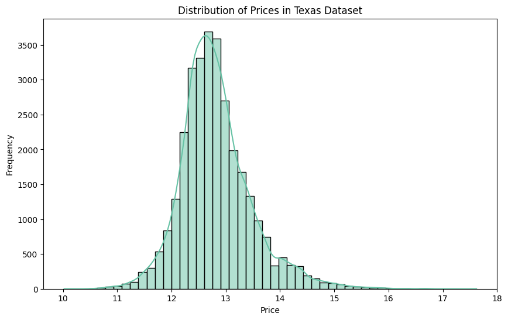

```
Median Price Rank by City in Texas Dataset:
 city
Austin         5.0
Dallas         4.0
Fort Worth     3.0
Houston        2.0
San Antonio    1.0
Name: price, dtype: float64
```

```python
#Now we will explore the data a bit more before visualizations and analysis

#Since most of data is right skewed, we will take the log of price for better visualization
df_tx['log_price'] = np.log(df_tx['price'] + 1)

#Distribution of Prices in Texas Dataset
plt.figure(figsize=(10,6))
sns.histplot(df_tx['log_price'], bins=50, kde=True)
plt.title('Distribution of Prices in Texas Dataset')
plt.xlabel('Price')
plt.ylabel('Frequency')
plt.show()
city_price_rank = df_tx.groupby('city')['price'].median().rank()
print('\nMedian Price Rank by City in Texas Dataset: \n', city_price_rank)
```

### Data Visualization

#### Pairplot

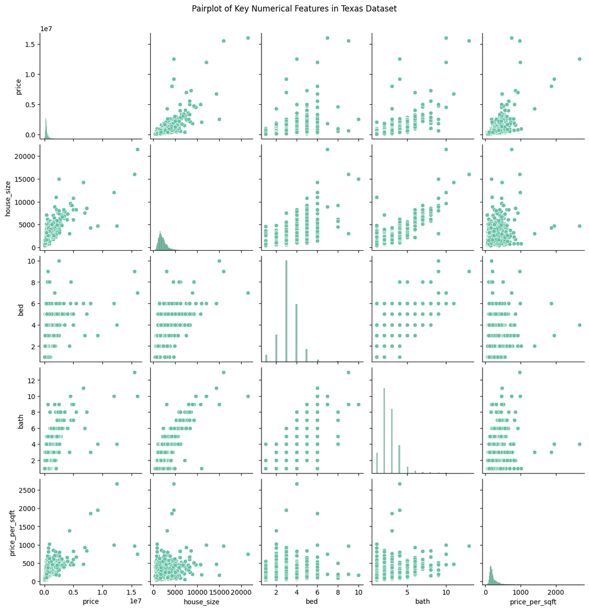

```python
#For Visualization,  I would like to start with a pairplot to see any initial relationships between numerical features

#To Speed up the plotting process, I will sample 3000 rows from the dataset
sampled_df = df_tx.sample(n=3000, random_state=42)


sns.pairplot(sampled_df[['price', 'house_size', 'bed', 'bath', 'price_per_sqft'  ]])
plt.suptitle('Pairplot of Key Numerical Features in Texas Dataset', y=1.02)
```

##### Key insights

1. Property Characteristics

The dataset includes key numerical features such as house size (sqft), number of bedrooms, number of bathrooms, and price per square foot.

House size ranges widely and is strongly right-skewed, with most homes between 1,500–3,500 sqft but a long tail of luxury large homes.

Bedrooms and bathrooms cluster tightly around 3–4 beds and 2–3 baths, showing typical residential configurations.

These variables show predictable relationships: larger homes generally have more beds and baths.

2. Pricing Patterns

Several pricing variables are included, such as sale price and price per square foot.

Sale price is extremely right-skewed, with most properties in typical price ranges but a significant number of high-value outliers (multi-million-dollar homes).

Price per square foot shows a similar pattern, with the majority of values concentrated under $300/sqft and a few extreme luxury spikes.

Price correlates most strongly with house size, indicating that square footage is the primary driver of valuation.

3. Temporal Trends

The dataset includes month and year information for property sales.

4. City-Level Variation

Comparisons across major Texas cities (Dallas, Houston, Austin, Fort Worth, San Antonio) show:

Austin consistently exhibits the highest median prices and the most variability, suggesting a strong luxury market.

Dallas and Houston show wide spreads and a large number of high-price outliers.

San Antonio and Fort Worth tend to have more clustered, lower-priced distributions.

These differences reinforce the role of location as a major determinant of housing price.

5. Relationships Between Variables (Pairplot Insights)

A pairplot across key features reveals:

A strong positive relationship between house size and price, the most significant structural pattern in the dataset.

Bedrooms and bathrooms increase proportionally with home size.

Price per sqft varies widely, indicating the influence of factors such as neighborhood, condition, and city.

Most features exhibit right-skewed distributions and outliers, suggesting preprocessing steps like log transformation or outlier handling may be appropriate.